# Support analysis for paper on Deaf Depression-free Life Expectancy

Rafael Rodrigues de Moraes

2024-05-18

This RMarkdown notebook serves as the official documentation of the steps undertaken to produce the data and graphics that will show up on the Deaf Depression-free Life Expectancy paper.

# R Packages

Basic packages were used to connect to databases (`DBI` and `RPostgres`), configure the complex survey schema (`survey`) and manipulate the data frames (`tidyverse`).

```r
library(tidyverse)
library(ggstats)
library(svglite)
library(DBI)
library(survey)
library(RPostgres)
```

# Connection to database

One of the containers hosts the `Postgres 14.0` database where all the data from Census and National Health Survey lie.

```r
# Connect to database 'pns'
conn <- dbConnect(
  RPostgres::Postgres(),
  dbname = Sys.getenv("PG_DB"),
  host = Sys.getenv("PG_HOST"),
  port = Sys.getenv("PG_PORT"),
  user = Sys.getenv("PG_USER"),
  password = Sys.getenv("PG_PASSWORD")
)
```

## Queries

The following two SQL-queries were used to retrieve only the necessary data from each table.

### Life table functions from Census

From all functions of the life table produced at the 2010th edition of the Brazilian Population Census, only the functions $l_x$, $_nL_x$ and $e_x$ are needed for this paper.

```sql
-- Abbreviated Life Tables
-- Brazilian Population Census 2010 (IBGE/Censo)
-- Source (accessed on September 7th, 2022):
--  ftp://ftp.ibge.gov.br/Tabuas_Abreviadas_de_Mortalidade/2010/tabelas_xls.zip

 select age_grp,   -- 5-year age
        sex,       -- both, male and female
        name,      -- life table functions
        value
   from censo2010.lifetables
  where name in ('lx', 'Lxn', 'Ex')
      ;
```

```r
# Life tables from 2010th Brazilian Population Census (IBGE)
censo2010_qry <- dbGetQuery( conn, statement = readr::read_file('qry_censo.sql') )

censo2010 <- censo2010_qry %>%
  pivot_wider(
    id_cols = c('age_grp', 'sex')
    ,names_from = 'name'
    ,values_from = 'value'
  ) %>%
  mutate( across( c(lx, Lxn, Ex), as.numeric) )
```

### PNS Survey

```sql
-- National Health Survey (PNS/IBGE)
-- Questionnaire (accessed on September 7th, 2022):
--   https://www.pns.icict.fiocruz.br/wp-content/uploads/2021/02/Questionario-PNS-2019.pdf

 select -- survey design variables
        upa_pns, v0024,
        v0028, v00281, v00282, v00283,    -- chosen respondent answers in the name of all persons of household
        -- v0029, v00291, v00292, v00293, -- answers from chosen respondent only
        -- v0030, v00301, v00302, v00303, -- answers from anthropometric questionaire
        -- variables for analyses
        j001,   -- health_perception (for validation purposes only...)
        c006,   -- sex
        c008,   -- age
        q092,   -- ever diagnosed with depression by a physician
        q11006, -- ever diagnosed with anxiety by a physician
        g058,   -- hearing impairment level
        g057,   -- hearing impairment level even using hearning devices
        g05801  -- knowdledge of Libras, the brazilian sign language
   from pns2019.microdata
  where v0028 ~ '\d+' -- (weight variable) v0028 not empty
    and v0015 = '01'  -- only effective and successful interviews
      ;
```

```r
# 2019th edition from National Health Survey (PNS/IBGE)
pns2019_qry <- dbGetQuery( conn, statement = readr::read_file('qry_pns.sql') )
pns2019_qry <- pns2019_qry %>%
  mutate(
    across( c(upa_pns,v0024,v0028,v00281,v00282,v00283,c008), as.numeric)
  )
```

# Complex Survey Design

The National Health Survey (PNS) is a complex survey consisting of strata, cluster and weights.

The same steps were followed in order to set up the survey design object and post-stratify it as listed in the official R package `PNSIBGE` (version 0.1.7).

```r
## Survey design (source: https://rdrr.io/cran/PNSIBGE/src/R/pns_design.R, accessed on September, 2nd 2022)
options(survey.lonely.psu="adjust")
options(survey.adjust.domain.lonely=TRUE)

pns2019_prior <- survey::svydesign(
  ids = ~upa_pns,
  strata = ~v0024,
  data = subset(pns2019_qry, !is.na(v0028)),
  weights = ~v0028,
  nest = TRUE
)
# Post-stratification
popc.types <- data.frame(
  v00283=as.character(unique(pns2019_qry$v00283)),
  Freq=as.numeric(unique(pns2019_qry$v00282))
)
popc.types <- popc.types[order(popc.types$v00283),]
pns2019_posterior <- survey::postStratify(
  design=pns2019_prior,
  strata=~v00283,
  population=popc.types
)
```

## Validation

Despite using exactly the same complex survey design, a full match with the government official statistics was not entirely possible.

[figure not shown]

PNS2019 - Validation with self-reported health perception

```r
# validation against
#   https://sidra.ibge.gov.br/tabela/7666#/n1/all/v/2667/p/all/c2/all/c12258/all/d/v2667%200/l/v,p+c2,t+c12258/resultado
round( svytable(formula=~j001+c006, design=subset(pns2019_posterior, c008 >=18))/1e3, 0) %>%
  as.data.frame() %>%
  mutate(
    tab7666 = case_when(
      j001 %in% c(1,2) ~ 1,
      j001 == 3 ~ 2,
      j001 %in% c(4,5) ~ 3,
    )
    ,tab7666 = factor( tab7666, levels = 1:3, labels = c('Muito ruim e ruim','Regular','Muito bom e bom'))
    ,c006 = factor( c006, levels = 1:2, labels = c('Masculino', 'Feminino'))
  ) %>%
  na.omit() %>%
  group_by(tab7666, c006) %>%
  summarise( n = sum(Freq) ) %>%
  pivot_wider(id_cols = tab7666, names_from = c006, values_from = n)
```

| tab7666 | Masculino | Feminino |
| --- | --- | --- |
| Muito ruim e ruim | 53296 | 54574 |
| Regular | 17646 | 24349 |
| Muito bom e bom | 3610 | 5696 |

```r
round( svytable(formula=~c006, design=subset(pns2019_posterior, c008 >= 18))/1e3, 0)
```

```
## c006
##     1     2
## 74553 84619
```

```r
round( sum(svytable(formula=~c006, design=subset(pns2019_posterior, c008 >= 18)))/1e3, 0)
```

```
## [1] 159171
```

*Conclusion:* although overall total and totals by sex are OK, among health perception the numbers do not match. Unfortunately it was not possible to reconcile the differences but as the total figures are the same, we proceed with the analysis.

# Deaf Depression-free Life Expectancy paper related analyses

```r
dfle_raw <- svytable(
  formula=~c008 + # age at interview date
    g058 +        # level of hearing impairment
    g057 +        # level of hearing impairment (despite use of hearing devices)
    c006 +        # sex
    g05801 +      # use of LIBRAS, the Brazilian sign language
    q092 +        # ever diagnosed with depression by a physician
    q11006,       # ever diagnosed with anxiety by a physician
  design = pns2019_posterior,
)
```

## Table 2: Libras users and prevalence of depression for respondents with age between 5 and 40 years, Brazil, 2019

```r
AGE_BREAKS <- c( 0, 1, seq(from=5,to=80, by=5), 1e3)
AGE_LABELS <- c('<1','1-4','5-9','10-14','15-19','20-24','25-29','30-34'
                ,'35-39','40-44','45-49','50-54','55-59','60-64','65-69'
                ,'70-74','75-79','80+')

dfle_pns <- dfle_raw %>%
  as.data.frame(stringsAsFactors = FALSE) %>%
  mutate(
    c008 = as.numeric(c008),
    sex = factor( c006, levels = 1:2, labels = c('male', 'female')),
    libras = factor( g05801, levels = 1:2, labels = c('yes', 'no')),
    age_grp = cut(
      c008,
      breaks = AGE_BREAKS,
      labels = AGE_LABELS,
      include.lowest = TRUE,
      right = FALSE
    ),
    combined = case_when(
      g057 == ' ' ~ g058,
      g058 == ' ' ~ g057,
    ),
    hearing_impairment_level = case_when(
      combined %in% c('3', '4') ~ 'Heavily or Fully impaired',
      combined %in% c('1', '2') ~ 'Not or mildly impaired',
      # TRUE ~ 'Ignored or missing information'
    ),
    hearing_impaired = case_when(
      combined == '4' ~ 'Fully impaired',
      combined == '3' ~ 'Heavily impaired',
      combined == '2' ~ 'Mildly impaired',
      combined == '1' ~ 'Not impaired',
      # TRUE ~ 'Ignored or missing information'
    ),
    diagnosed_depression = q092,
    diagnosed_anxiety = q11006,
  )

summary_aux <- dfle_pns %>%
  filter( c008 >= 5, c008 <= 40 ) %>%
  group_by(combined, hearing_impaired, libras, diagnosed_depression) %>%
  summarise( n = sum(Freq))
```

```
## You can override using the `.groups` argument.
```

```r
summary_aux %>%
  group_by(combined, hearing_impaired, libras) %>%
  summarise( n = sum(n)) %>%
  na.omit() %>%
  pivot_wider(id_cols = c(1,2), names_from = 3, values_from=4) %>%
  mutate( pct_libras_users = yes / (yes+no)) %>%
  select( -c(yes,no)) %>%
  left_join( summary_aux %>%
               group_by(combined, hearing_impaired, diagnosed_depression) %>%
               summarise( n = sum(n)) %>%
               na.omit() %>%
               pivot_wider(id_cols = c(1,2), names_from = 3, values_from=4) %>%
               mutate( pct_depression = `1` / (`1`+`2`)) %>%
               select( -c(3:5))
             ) %>%
  left_join( summary_aux %>%
               filter( libras == 'yes') %>%
               group_by(combined, hearing_impaired, diagnosed_depression) %>%
               summarise( n = sum(n)) %>%
               na.omit() %>%
               pivot_wider(id_cols = c(1,2), names_from = 3, values_from=4) %>%
               mutate( pct_depression_among_libras_users = `1` / (`1`+`2`)) %>%
               select( -c(3:5))
             ) %>%
  ungroup() %>%
  select( -combined ) %>%
  knitr::kable()
```

| hearing_impaired | pct_libras_users | pct_depression | pct_depression_among_libras_users |
| --- | --- | --- | --- |
| Not impaired | 0.0284534 | 0.0763576 | 0.1222703 |
| Mildly impaired | 0.0559718 | 0.0790343 | 0.1570855 |
| Heavily impaired | 0.1292562 | 0.1494309 | 0.0298612 |
| Fully impaired | 0.6133677 | 0.0550637 | 0.0384861 |

## Figure 1: Depression prevalence by sex and age band among grouped levels of hearing impairment, Brazil, 2019

```r
AGE_BREAKS <- c( 0, 1, seq(from=5,to=80, by=5), 1e3)
AGE_LABELS <- c('<1','1-4','5-9','10-14','15-19','20-24','25-29','30-34'
                ,'35-39','40-44','45-49','50-54','55-59','60-64','65-69'
                ,'70-74','75-79','80+')

dfle_pns <- dfle_raw %>%
  as.data.frame(stringsAsFactors = FALSE) %>%
  mutate(
    c008 = as.numeric(c008),
    sex = factor( c006, levels = 1:2, labels = c('male', 'female')),
    libras = factor( g05801, levels = 1:2, labels = c('yes', 'no')),
    age_grp = cut(
      c008,
      breaks = AGE_BREAKS,
      labels = AGE_LABELS,
      include.lowest = TRUE,
      right = FALSE
    ),
    combined = case_when(
      g057 == ' ' ~ g058,
      g058 == ' ' ~ g057,
    ),
    hearing_impairment_level = case_when(
      combined %in% c('3', '4') ~ 'Heavily or Fully impaired',
      combined %in% c('1', '2') ~ 'Not or mildly impaired',
      # TRUE ~ 'Ignored or missing information'
    ),
    hearing_impaired = case_when(
      combined == '4' ~ 'Fully impaired',
      combined == '3' ~ 'Heavily impaired',
      combined == '2' ~ 'Mildly impaired',
      combined == '1' ~ 'Not impaired',
      # TRUE ~ 'Ignored or missing information'
    ),
    diagnosed_depression = q092,
    diagnosed_anxiety = q11006,
  )

# ever diagnosed with depression by a physician (g058)
depr_by_impairment <- dfle_pns %>%
  na.omit() %>%
  group_by( hearing_impairment_level, age_grp, sex, diagnosed_depression) %>%
  summarise( n = sum( Freq ) ) %>%
  filter( diagnosed_depression != ' ') %>%
  pivot_wider( id_cols = c(1,2,3), names_from = 4, values_from = n) %>%
  rename( yes = `1`, no = `2`)
```

```
## 'sex'. You can override using the `.groups` argument.
```

```r
depr_by_impairment <- bind_rows(
  depr_by_impairment,
  depr_by_impairment %>%
  group_by( hearing_impairment_level, age_grp) %>%
  summarise( yes = sum(yes), no = sum(no)) %>%
  transmute( hearing_impairment_level, age_grp, sex = 'both', yes, no)
) %>% mutate(
    pct = ifelse( yes+no== 0, 0, yes / (yes + no))
  )
```

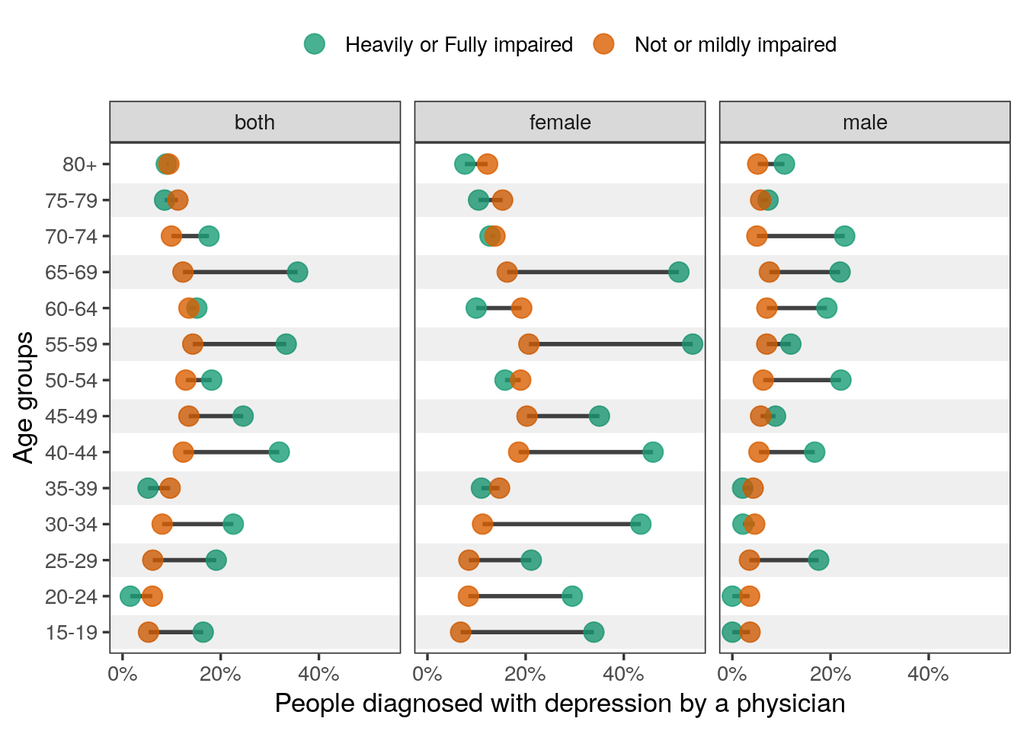

```r
fig1 <- depr_by_impairment %>%
  filter(!age_grp %in% c('<1','1-4','5-9','10-14')) %>%
  ggplot(
    aes(
      x = age_grp,
      y = pct,
      group = sex,
      colour = hearing_impairment_level
    )
  ) +
  geom_line(
    aes(group = age_grp),
    size = 1,
    color = "grey26",
    alpha = 1
    ) +
  geom_point(size = 4.3, alpha = .8) +
  geom_stripped_cols(color = "white") +
  labs(
    y = 'People diagnosed with depression by a physician'
    ,x = 'Age groups'
    ,group = ''
    ,colour = ''
  ) +
  theme_bw(base_size = 13) +
  theme(
    panel.grid = element_blank(),
    legend.position = 'top'
  )+
  facet_grid(~sex) +
  coord_flip() +
  scale_color_brewer(palette = "Dark2") +
  scale_y_continuous(
    labels = scales::percent_format(scale = 100)
    )

ggsave(
  filename = 'fig01.png',
  plot = fig1,
  width = 7,
  height = 5
)

ggsave(
  filename = 'fig01.pdf',
  plot = fig1,
  width = 7,
  height = 5
)

ggsave(
  filename = 'fig01.svg',
  plot = fig1,
  width = 7,
  height = 5
)

fig1
```

## Table 3: Comparison by sex, age, and grouped level of hearing impairment of life expectancy and depression-free life expectancy, Brazil

```r
AGE_BREAKS <- c( 0, 1, seq(from=5,to=90, by=5), 1e3)
AGE_LABELS <- c('<1','1-4','5-9','10-14','15-19','20-24','25-29','30-34'
                ,'35-39','40-44','45-49','50-54','55-59','60-64','65-69'
                ,'70-74','75-79','80-84','85-89','90+')

dfle_pns <- dfle_raw %>%
  as.data.frame(stringsAsFactors = FALSE) %>%
  mutate(
    c008 = as.numeric(c008),
    sex = factor( c006, levels = 1:2, labels = c('male', 'female')),
    libras = factor( g05801, levels = 1:2, labels = c('yes', 'no')),
    age_grp = cut(
      c008,
      breaks = AGE_BREAKS,
      labels = AGE_LABELS,
      include.lowest = TRUE,
      right = FALSE
    ),
    combined = case_when(
      g057 == ' ' ~ g058,
      g058 == ' ' ~ g057,
    ),
    hearing_impairment_level = case_when(
      combined %in% c('3', '4') ~ 'Heavily or Fully impaired',
      combined %in% c('1', '2') ~ 'Not or mildly impaired',
      # TRUE ~ 'Ignored or missing information'
    ),
    hearing_impaired = case_when(
      combined == '4' ~ 'Fully impaired',
      combined == '3' ~ 'Heavily impaired',
      combined == '2' ~ 'Mildly impaired',
      combined == '1' ~ 'Not impaired',
      # TRUE ~ 'Ignored or missing information'
    ),
    diagnosed_depression = q092,
    diagnosed_anxiety = q11006,
  )

# ever diagnosed with depression by a physician (g058)
depr_by_impairment <- dfle_pns %>%
  na.omit() %>%
  group_by( hearing_impairment_level, age_grp, sex, diagnosed_depression) %>%
  summarise( n = sum( Freq ) ) %>%
  filter( diagnosed_depression != ' ') %>%
  pivot_wider( id_cols = c(1,2,3), names_from = 4, values_from = n) %>%
  rename( yes = `1`, no = `2`)
```

```
## 'sex'. You can override using the `.groups` argument.
```

```r
depr_by_impairment <- bind_rows(
  depr_by_impairment,
  depr_by_impairment %>%
  group_by( hearing_impairment_level, age_grp) %>%
  summarise( yes = sum(yes), no = sum(no)) %>%
  transmute( hearing_impairment_level, age_grp, sex = 'both', yes, no)
) %>% mutate(
    pct = ifelse( yes+no== 0, 0, yes / (yes + no))
  )
# ever diagnosed with anxiety by a physician (q11006)
anx_by_impairment <- dfle_pns %>%
  na.omit() %>%
  group_by( hearing_impairment_level, age_grp, sex, diagnosed_anxiety) %>%
  summarise( n = sum( Freq ) ) %>%
  filter( diagnosed_anxiety != ' ') %>%
  pivot_wider( id_cols = c(1,2,3), names_from = 4, values_from = n) %>%
  rename( yes = `1`, no = `2`)
```

```
## 'sex'. You can override using the `.groups` argument.
```

```r
anx_by_impairment <- bind_rows(
  anx_by_impairment,
  anx_by_impairment %>%
    group_by( hearing_impairment_level, age_grp) %>%
    summarise( yes = sum(yes), no = sum(no)) %>%
    transmute( hearing_impairment_level, age_grp, sex = 'both', yes, no)
) %>% mutate(
  pct = ifelse( yes+no== 0, 0, yes / (yes + no))
)
prevalences <- bind_rows(
  depr_by_impairment %>%
  mutate( disease = 'depression'),
  anx_by_impairment %>%
  mutate( disease = 'anxiety') )

dfle <- prevalences %>%
  transmute(disease, sex, hearing_impairment_level, age_grp, pix = pct) %>%
  arrange( disease, sex,hearing_impairment_level, desc(age_grp) ) %>%
  na.omit() %>%
  left_join(censo2010, by = c('age_grp','sex')) %>%
  mutate( aux = (1-pix)*Lxn ) %>%
  group_by(disease, sex, hearing_impairment_level) %>%
  mutate(
    dfle = cumsum(aux)/lx,
    age_grp = factor( age_grp, levels = AGE_LABELS),
    dfle_over_Ex = dfle / Ex
    ) %>%
  select( -aux ) %>%
  arrange( disease, sex, hearing_impairment_level, age_grp )

dfle %>%
  filter(
    disease == 'depression',
    age_grp %in% c('<1', '20-24', '40-44','60-64','80-84')
  ) %>%
  mutate(
    age = case_when(
      age_grp == '<1' ~ 0,
      age_grp == '20-24' ~ 20,
      age_grp == '40-44' ~ 40,
      age_grp == '60-64' ~ 60,
      age_grp == '80-84' ~ 80,
    )
  ) %>%
  pivot_wider(
    id_cols = c('sex', 'age', 'Ex'),
    names_from = 'hearing_impairment_level',
    values_from = 'dfle'
  ) %>%
  select( 1,2,3,5,4) %>%
  knitr::kable()
```

| sex | age | Ex | Not or mildly impaired | Heavily or Fully impaired |
| --- | --- | --- | --- | --- |
| both | 0 | 73.76 | 67.763919 | 62.838749 |
| both | 20 | 55.78 | 49.868340 | 45.357838 |
| both | 40 | 37.64 | 33.010672 | 29.256212 |
| both | 60 | 21.06 | 18.679606 | 17.389671 |
| both | 80 | 8.61 | 7.817028 | 7.875093 |
| female | 0 | 77.38 | 68.318001 | 60.001589 |
| female | 20 | 59.12 | 50.177388 | 43.024959 |
| female | 40 | 40.06 | 33.103358 | 28.974626 |
| female | 60 | 22.61 | 19.155894 | 18.457914 |
| female | 80 | 9.07 | 7.962645 | 8.337238 |
| male | 0 | 70.21 | 67.348479 | 64.173416 |
| male | 20 | 52.46 | 49.679551 | 46.211961 |
| male | 40 | 35.12 | 32.984064 | 29.613413 |
| male | 60 | 19.34 | 18.168162 | 16.140620 |
| male | 80 | 7.97 | 7.606610 | 7.326711 |

## Figure 2: Proportional impact of depression on life expectancy according to sex and grouped hearing impairment level, Brazil

```r
AGE_BREAKS <- c( 0, 1, seq(from=5,to=90, by=5), 1e3)
AGE_LABELS <- c('<1','1-4','5-9','10-14','15-19','20-24','25-29','30-34'
                ,'35-39','40-44','45-49','50-54','55-59','60-64','65-69'
                ,'70-74','75-79','80-84','85-89','90+')

dfle_pns <- dfle_raw %>%
  as.data.frame(stringsAsFactors = FALSE) %>%
  mutate(
    c008 = as.numeric(c008),
    sex = factor( c006, levels = 1:2, labels = c('male', 'female')),
    libras = factor( g05801, levels = 1:2, labels = c('yes', 'no')),
    age_grp = cut(
      c008,
      breaks = AGE_BREAKS,
      labels = AGE_LABELS,
      include.lowest = TRUE,
      right = FALSE
    ),
    combined = case_when(
      g057 == ' ' ~ g058,
      g058 == ' ' ~ g057,
    ),
    hearing_impairment_level = case_when(
      combined %in% c('3', '4') ~ 'Heavily or Fully impaired',
      combined %in% c('1', '2') ~ 'Not or mildly impaired',
      # TRUE ~ 'Ignored or missing information'
    ),
    hearing_impaired = case_when(
      combined == '4' ~ 'Fully impaired',
      combined == '3' ~ 'Heavily impaired',
      combined == '2' ~ 'Mildly impaired',
      combined == '1' ~ 'Not impaired',
      # TRUE ~ 'Ignored or missing information'
    ),
    diagnosed_depression = q092,
    diagnosed_anxiety = q11006,
  )

# ever diagnosed with depression by a physician (g058)
depr_by_impairment <- dfle_pns %>%
  na.omit() %>%
  group_by( hearing_impairment_level, age_grp, sex, diagnosed_depression) %>%
  summarise( n = sum( Freq ) ) %>%
  filter( diagnosed_depression != ' ') %>%
  pivot_wider( id_cols = c(1,2,3), names_from = 4, values_from = n) %>%
  rename( yes = `1`, no = `2`)
```

```
## 'sex'. You can override using the `.groups` argument.
```

```r
depr_by_impairment <- bind_rows(
  depr_by_impairment,
  depr_by_impairment %>%
  group_by( hearing_impairment_level, age_grp) %>%
  summarise( yes = sum(yes), no = sum(no)) %>%
  transmute( hearing_impairment_level, age_grp, sex = 'both', yes, no)
) %>% mutate(
    pct = ifelse( yes+no== 0, 0, yes / (yes + no))
  )
# ever diagnosed with anxiety by a physician (q11006)
anx_by_impairment <- dfle_pns %>%
  na.omit() %>%
  group_by( hearing_impairment_level, age_grp, sex, diagnosed_anxiety) %>%
  summarise( n = sum( Freq ) ) %>%
  filter( diagnosed_anxiety != ' ') %>%
  pivot_wider( id_cols = c(1,2,3), names_from = 4, values_from = n) %>%
  rename( yes = `1`, no = `2`)
```

```
## 'sex'. You can override using the `.groups` argument.
```

```r
anx_by_impairment <- bind_rows(
  anx_by_impairment,
  anx_by_impairment %>%
    group_by( hearing_impairment_level, age_grp) %>%
    summarise( yes = sum(yes), no = sum(no)) %>%
    transmute( hearing_impairment_level, age_grp, sex = 'both', yes, no)
) %>% mutate(
  pct = ifelse( yes+no== 0, 0, yes / (yes + no))
)
```

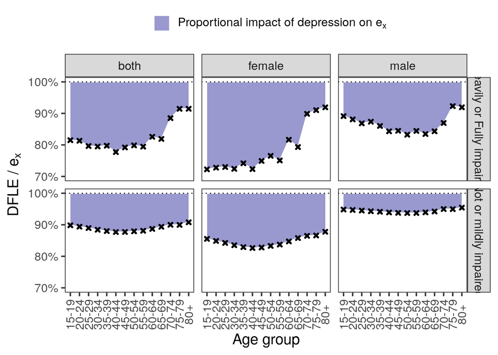

```r
prevalences <- bind_rows(
  depr_by_impairment %>%
  mutate( disease = 'depression'),
  anx_by_impairment %>%
  mutate( disease = 'anxiety') )

dfle <- prevalences %>%
  transmute(disease, sex, hearing_impairment_level, age_grp, pix = pct) %>%
  arrange( disease, sex,hearing_impairment_level, desc(age_grp) ) %>%
  na.omit() %>%
  left_join(censo2010, by = c('age_grp','sex')) %>%
  mutate( aux = (1-pix)*Lxn ) %>%
  group_by(disease, sex, hearing_impairment_level) %>%
  mutate(
    dfle = cumsum(aux)/lx,
    age_grp = factor( age_grp, levels = AGE_LABELS),
    dfle_over_Ex = dfle / Ex
    ) %>%
  select( -aux ) %>%
  arrange( disease, sex, hearing_impairment_level, age_grp )


fig2 <- dfle %>%
  filter(disease == 'depression') %>%
  filter(!age_grp %in% c('<1','1-4','5-9','10-14','85-89','90+')) %>%
  mutate(
    age_grp = as.character(age_grp),
    age_grp = case_when(
      age_grp == '80-84' ~ '80+',
      TRUE ~ as.character(age_grp)
    )
  ) %>%
  ggplot(
    aes(
    x = age_grp,
    y = dfle_over_Ex,
    shape = sex,
    group = hearing_impairment_level
    )
  ) +
  geom_ribbon(
    aes(
      ymin = dfle_over_Ex,
      ymax = 1,
      fill = "Gap"
      ),
    alpha = .4,
    color = "white"
  ) +
  geom_hline(yintercept = 1, linetype = "dotted", color = "black") +
  geom_point(size = .8, shape = 4, stroke = 1.5) +
  labs(
    y = expression("DFLE / e"[x]),
    x = 'Age group',
    fill = expression("Proportional impact of disease on e"[x])
  )+
  theme_bw(base_size = 15) +
  theme(
    legend.position = "top",
    axis.text.x = element_text(angle = 90, vjust = .5),
    panel.grid = element_blank()
    ) +
  facet_grid(hearing_impairment_level ~ sex) +
  scale_fill_manual(
    name = "",
    values = "darkblue",
    labels = expression("Proportional impact of depression on e"[x])
  ) +
  scale_y_continuous(
    limits = c(0.7, 1),
    labels = scales::percent_format(scale = 100)
  )

ggsave(
  filename = 'fig02.png',
  plot = fig2,
  width = 10,
  height = 8
)

ggsave(
  filename = 'fig02.pdf',
  plot = fig2,
  width = 10,
  height = 8
)

ggsave(
  filename = 'fig02.svg',
  plot = fig2,
  width = 10,
  height = 8
)

fig2
```

## Figure 03 (Supplementary Material): Depression prevalence among users of Brazilian Sign Language by 5-year age group and sex, Brazil, 2019

```r
# among users of Libras
# ever diagnosed with depression by a physician (g058)
depr_libras <- dfle_pns %>%
  filter( g05801 == '1', combined %in% c('2','3','4') ) %>% # only users of Libras with at least some hearing impairment
  group_by( age_grp, sex, diagnosed_depression) %>%
  summarise( n = sum( Freq ) ) %>%
  filter( diagnosed_depression != ' ') %>%
  pivot_wider( id_cols = c(1,2), names_from = 3, values_from = n ) %>%
  rename( yes = `1`, no = `2`)
```

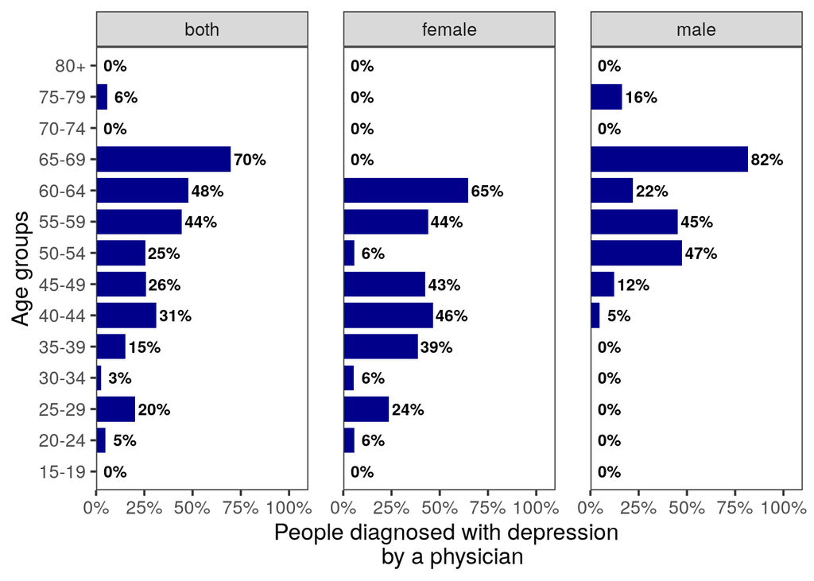

```r
depr_libras <- bind_rows(
  depr_libras,
  depr_libras %>%
    group_by(age_grp) %>%
    summarise( yes = sum(yes), no = sum(no)) %>%
    transmute( age_grp, sex = 'both', yes, no)
  ) %>%
  mutate( pct = ifelse( yes+no== 0, 0, yes / (yes + no)) )

fig3 <- depr_libras %>%
  filter(!age_grp %in% c('<1','1-4','5-9','10-14','85-89','90+')) %>%
  mutate(
    age_grp = as.character(age_grp),
    age_grp = case_when(
      age_grp == '80-84' ~ '80+',
      TRUE ~ as.character(age_grp)
    )
  ) %>%
  ggplot(
    aes(
      x = age_grp,
      y = pct,
      group = sex
      )
  ) +
  geom_col(fill = "darkblue", width = .8) +
  geom_text(
    aes(label = scales::percent(round(pct, 2))),
    size = 3.5,
    nudge_y = 1.5/15,
    fontface = "bold",
    show.legend = FALSE,
    angle = 0
  ) +
  labs(
    y = 'People diagnosed with depression \n by a physician'
    ,x = 'Age groups'
    ,group = ''
    ,colour = ''
    ,fill = ''
  )+
  theme_bw(base_size = 14) +
  theme(
    panel.grid = element_blank(),
    panel.spacing.x = unit(1.5, "lines"),
    legend.position = 'none'
  ) +
  scale_color_brewer(palette = "Dark2") +
  scale_y_continuous(
    limits = c(0, 1.10),
    labels = scales::percent_format(scale = 100),
    expand = c(0, 0)
  )+
  facet_wrap(~ sex) + coord_flip()

ggsave(
  filename = 'fig03.png',
  plot = fig3,
  width = 9,
  height = 5
)

ggsave(
  filename = 'fig03.pdf',
  plot = fig3,
  width = 9,
  height = 5
)

ggsave(
  filename = 'fig03.svg',
  plot = fig3,
  width = 9,
  height = 5
)

fig3
```

## Figure 04 (Supplementary Material): Depression prevalence by 5-year age group, sex and knowledge of Brazilian Sign Language

```r
# Depression (diagnosed by a physician)
# Comparison between users and not users of Libras
depr_compr <- dfle_pns %>%
  group_by( age_grp, sex, libras, diagnosed_depression) %>%
  summarise( n = sum( Freq ) ) %>%
  filter( diagnosed_depression != ' ') %>%
  pivot_wider( id_cols = c(1,2,3), names_from = 4, values_from = n ) %>%
  rename( yes = `1`, no = `2`)
depr_compr <- bind_rows(
  depr_compr,
  depr_compr %>%
    group_by( age_grp, libras) %>%
    summarise( yes = sum(yes), no = sum(no)) %>%
    transmute( age_grp, sex = 'both', libras, yes, no)
) %>%
  mutate( pct = ifelse( yes + no == 0, 0, yes / (yes + no)) )
```

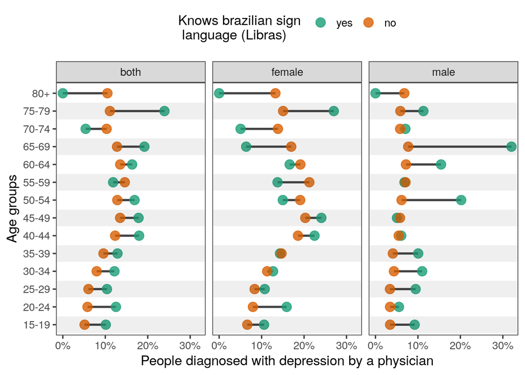

```r
fig4 <- depr_compr %>%
  filter(!age_grp %in% c('<1','1-4','5-9','10-14','85-89','90+')) %>%
  mutate(
    age_grp = as.character(age_grp),
    age_grp = case_when(
      age_grp == '80-84' ~ '80+',
      TRUE ~ as.character(age_grp)
    )
  ) %>%
  na.omit() %>%
  ggplot(
    aes(
      x = age_grp,
      y = pct,
      group = libras,
      colour = libras
    )
  )+
  geom_line(
    aes(group = age_grp),
    size = 1,
    color = "grey26",
    alpha = 1
  ) +
  geom_point(size = 4, alpha = .8) +
  geom_stripped_cols(color = "white") +
  labs(
    y = 'People diagnosed with depression by a physician'
    ,x = 'Age groups'
    ,group = 'Knows brazilian sign \n language (Libras)'
    ,colour = 'Knows brazilian sign \n language (Libras)'
  )+
  theme_bw(base_size = 13) +
  theme(
    legend.position = 'top',
    panel.grid = element_blank()
  )+
  scale_color_brewer(palette = "Dark2") +
  scale_y_continuous(labels =
  scales::percent_format(scale = 100)) +
  facet_wrap(~sex) +
  coord_flip()

ggsave(
  filename = 'fig04.png',
  plot = fig4,
  width = 7,
  height = 5
)

ggsave(
  filename = 'fig04.pdf',
  plot = fig4,
  width = 7,
  height = 5
)

ggsave(
  filename = 'fig04.svg',
  plot = fig4,
  width = 7,
  height = 5
)


fig4
```